# chapter-1

An Overview of Issues in Criminological Theory

## What is Criminology?

The **scientific** study of why people commit crime and why some places have more crime than other places

- How does a journalistic perspective on crime differ from a criminologist’s perspective?  
  (hint: starts with an **s**)
1. The criminologist perspective relies on the **s**cientific method!!!
2. Journalist rely on *one incident of crime* and then make inferences but criminologist rely on many many *many incidents of crime (Think in the thousands!!!)*

## Okay, but how do we go from the journalistic perspective to the criminologist perspective?

[figure not shown]

image: giphy

## Scientific Method

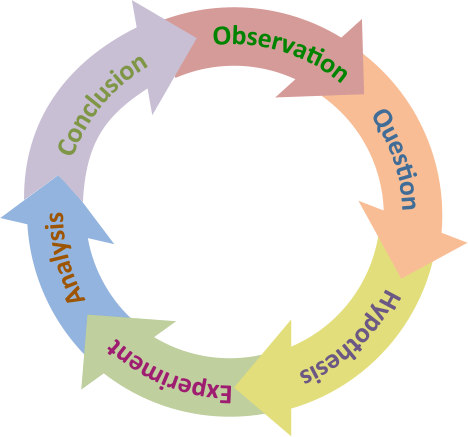

## What is a Theory?

**A set of concepts linked together by a series of statements to explain why an event or phenomenon occurs.**

In other words, they explain how and why the world works the way it does!

Famous examples: *Theory of Relativity*, *Germ Theory of Disease*, *Theory of Evolution*

Criminology has a lotttt of theories and we’ll discuss quite a few in the upcoming lectures.

# Group Discussion!!!

## Group Discussion!!!

`05:00`

Within your group, discuss and reach a consensus on what the factors, or your group’s theory, that explains: the relationship between economic hardship and criminal behavior.

Elect one speaker to present your point.

## Social Disorganization Theory

This attributes variations in crime rates to the structural and cultural characteristics of communities.

It suggests that a community’s ability to maintain social order and prevent criminal behavior is influenced by its level of social cohesion, collective efficacy, and structural stability.

## Burgress’s Concetric Zones

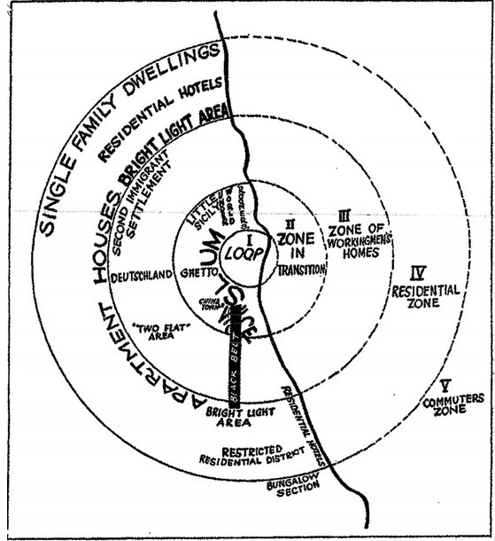

**Place Not Race!!!**

**High Crime in the Zone of Transition**

- Population Turnover and Heterogeneity
- Economic Disadvantage
- Conflicting cultural norms and values

**Low Crime in Peripheral Neighborhoods**

- Stable, Homegenous Populations
- Higher Social Economic Status (SES)
- Fewer conflicts on cultural norms or values

image: UW Sociology

## Social Disorganization

Areas like the **zone in transition (zone 2)** often experience higher crime rates due to poverty, residential turnover, and ethnic heterogeneity, which leads to weakened social controls.

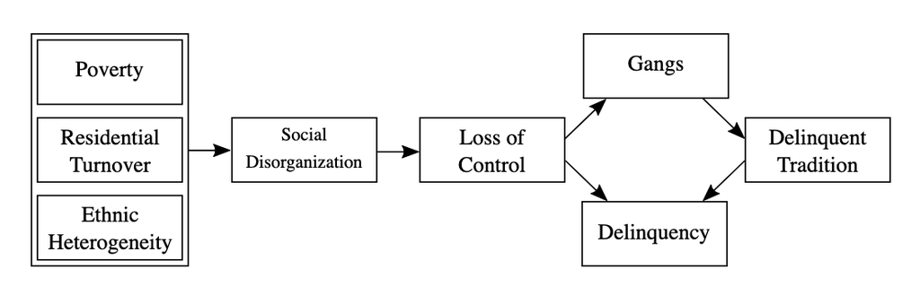

image: UW Sociology

## Recap!!

- Scientific Method
- Theory
- Social Disorganization Theory

## What is Crime?

[figure not shown]

image: CSI.net

## What is Crime?

An act or omission that **violates the laws established by a governing authority** and is punishable by the state or another authorized entity.

Crimes are generally categorized based on their **severity and nature**, including:

- **Felonies**: Serious offenses such as murder, rape, or armed robbery, often punishable by imprisonment for more than a year or even the death penalty in some jurisdictions.
- **Misdemeanors**: Less severe offenses such as petty theft or vandalism, typically punishable by fines, community service, or imprisonment for less than a year.
- **Infractions**: Minor violations like traffic offenses or public disturbances, usually resulting in fines.
- The legal definition of crime varies across jurisdictions but often involves two essential components: **Mala in se** & **Mala prohibita**

## Mala in se

*“Evil in itself”*

- Acts considered inherently immoral, evil, or wrong by their very nature, regardless of whether they are prohibited by law.
- Examples?
- Murder, rape, robbery, assault, etc..

## Mala prohibita

*“Evil because prohibited”*

- Acts that are not inherently immoral but are deemed illegal because they violate a statute, regulation, or law established by governing authorities.
- Examples?
- Speeding, cheating on taxes, *prostitution*, *gambling*, *drug-use*, etc..

## How Are Criminological Theories Classified?

Criminological theories are categorized based on their core concepts, assumptions, and characteristics, which typically align with broader paradigms.

A paradigm refers to a universally recognized set of concepts, theories, methods, and standards that define a scientific discipline during a particular period.

Famous Examples: *Copernican Paradigm*, *Newtonian Paradigm*, *Darwinian Paradigm*

# The Four Major Paradigms

## Classical School

Free Will and Rational Decision-Making

Individuals possess free will and choose to commit crimes through rational decision-making. This involves weighing the potential costs and risks against the benefits (i.e., maximizing pleasure and minimizing pain).

Foundations of Deterrence and Rational Choice Theories

The Classical School emphasizes the importance of deterrence and the role of rational choice in understanding criminal behavior.

- Any problems with this perspective?

## Positivism

Lack of Free Will and Rationality

Positivism argues that individuals do not exercise free will or rationality when deciding to commit crimes.

External Influences on Criminal Behavior

Crime is attributed to factors beyond an individual’s control, such as genetics, intelligence (IQ), education, economic conditions, peer influences, and other environmental or biological determinants.

- Any problems with this perspective?

## Conflict or Critical Perspectives

Law as a Tool of Authority

The law is viewed as a reactionary tool used by those in power to enforce control and restraint over less powerful groups.

Focus on Groups Over Individuals Emphasizes the dynamics between social groups rather than focusing on individual behavior.

Key Theoretical Foundations

Includes Marxist theories, feminist theories, and perspectives on the experiences of marginalized or subordinated groups (e.g., Black communities in the United States).

- Any problems with this perspective?

## Integrated Theories

Combining Explanatory Models

Integrated theories merge key elements from different explanatory models into a cohesive theoretical framework, aiming to provide a more comprehensive understanding of crime and its causes.

- Any problems with this perspective?

## Additional Classifications

Micro-Levels of Analysis

Focuses on individual behavior, decision-making, and personal characteristics.

- What paradigm aligns best here?

Macro-Levels of Analysis

Examines group dynamics, societal structures, and broader social patterns.

- What paradigm aligns best here?

## Characteristics of a Good Theory

*Parsimony*

The theory should be simple yet powerful, explaining phenomena with minimal assumptions.

*Testability*

Must be falsifiable and allow for empirical testing.

*Empirical Validity*

Supported by research evidence and consistently confirmed by data.

*Scope*

Explains a wide range of phenomena or has a broad applicability.

*Logical Consistency*

Internally coherent, avoiding contradictions while explaining phenomena effectively.

# Group Discussion!!!

## Group Discussion!!!

`05:00`

With the four paradigms and the ‘characteristics of a good theory’ in mind, discuss and present which paradigm explains *violent crime* the best?

Elect one speaker to present your point.

## Recap

The Four Major Paradigms

Characteristics of a Good Theory

## Criteria for Determining Causality

Temporal Ordering

**X (predictor)** must occur before **Y (outcome)** to establish a cause-effect relationship.

Correlation

Examines the strength and direction of the relationship between **X** and **Y**.

- How much does **X** influence changes in **Y**?
- Are the changes positive, negative, or neutral?

Controlling for Spuriousness

To confirm that **X** causes **Y**, account for potential confounding variables (**Z**).

- Rule out other factors that might explain the observed association.

## Measures of Crime

Crime is measured and collected using three major data resources:

[**Uniform Crime Report** (UCR)](https://www.fbi.gov/how-we-can-help-you/more-fbi-services-and-information/ucr)

[**National Crime Victimization Survey (NCVS)**](https://bjs.ojp.gov/data-collection/ncvs)

Self-report data - commonly collected by scientist and think-tanks (e.g., [RAND](https://www.rand.org/))

## Rates of Crime

Regional and City Differences

Variation in cities across the US. Some explanations are due to economic and variations in population density wihtin large cities

Age

The age-crime curve

Gender

Males are much more likely to commit crime

## The Age-Crime Curve

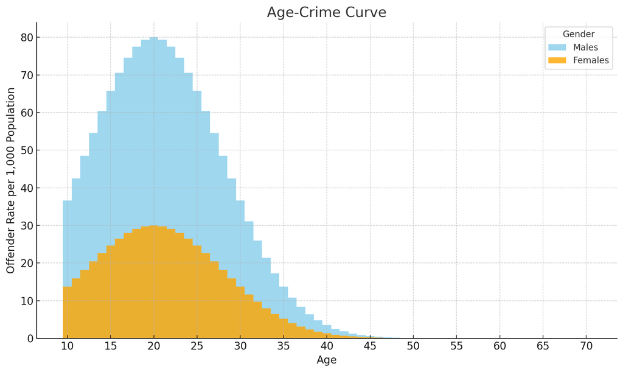

## That’s All Folks

[figure not shown]

image: giphy